# report

2024-03-28

# Class Exercise 1

## Data Import

data source: https://www.europeansocialsurvey.org/data-portal

## Data Preparation

```
## # A tibble: 10 × 2
##    stfeco trstplt
##     <dbl>   <dbl>
##  1      8       5
##  2      8       3
##  3      5       5
##  4      6       3
##  5      7       7
##  6      9       5
##  7      1       0
##  8      7       3
##  9      8       1
## 10      7       4
```

## Research Question.

Do people who are satisfied with present state of economy in country have more trust in politicians?

## Empirical Hypothesis

People that are more satisfied with present state of economy in country might have more trust in their politicians. This hypothesis suggests that there is a positive correlation between economic satisfaction and trust in politicians. It implies that individuals who perceive the economy as doing well are more inclined to trust political leaders, as they may attribute economic prosperity to the policies and actions of those leaders.

## Hypothesis Testing

### 1. Descriptive Statistics

```
##    Min. 1st Qu.  Median    Mean 3rd Qu.    Max.
##   0.000   4.000   5.000   5.254   7.000  10.000
```

```
##    Min. 1st Qu.  Median    Mean 3rd Qu.    Max.
##   0.000   2.000   4.000   3.673   5.000  10.000
```

The descriptive statistics suggest than economic satisfaction is generally rated better than the trust in politicians (higher mean and median values).

### 2. Linear Regression

```
##
## Call:
## lm(formula = trust_politicians ~ econ_satisfaction, data = data_prep)
##
## Residuals:
##     Min      1Q  Median      3Q     Max
## -6.1147 -1.5143 -0.0287  1.4570  9.0287
##
## Coefficients:
##                   Estimate Std. Error t value Pr(>|t|)
## (Intercept)       0.971296   0.022890   42.43   <2e-16 ***
## econ_satisfaction 0.514344   0.003943  130.44   <2e-16 ***
## ---
## Signif. codes:  0 '***' 0.001 '**' 0.01 '*' 0.05 '.' 0.1 ' ' 1
##
## Residual standard error: 2.125 on 47619 degrees of freedom
## Multiple R-squared:  0.2633, Adjusted R-squared:  0.2632
## F-statistic: 1.702e+04 on 1 and 47619 DF,  p-value: < 2.2e-16
```

According to the linear regression the relationship is statistically significant on the 1% CI and as expected positive.

```
##   Economic_Satisfaction Trust_in_Politicians Predicted_Trust
## 1                     8                    5        5.086044
## 2                     8                    3        5.086044
## 3                     5                    5        3.543013
## 4                     6                    3        4.057357
## 5                     7                    7        4.571701
## 6                     9                    5        5.600388
```

### 3. Pearson Correlation

```
## [1] 0.5130843
```

## Plots

### Histograms

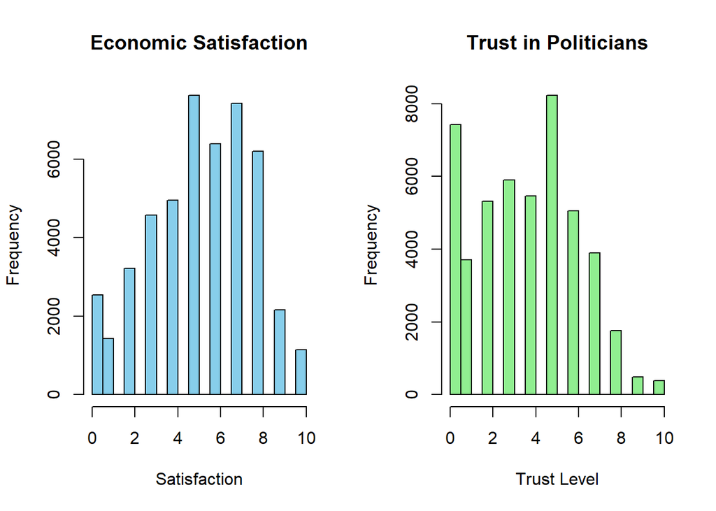

There are quite a lot of 0 or 1 values at the trust values (meaning no or almost no trust) and very few above 8. For economic satisfaction the values 5-8 were selected the most.

### Boxplots

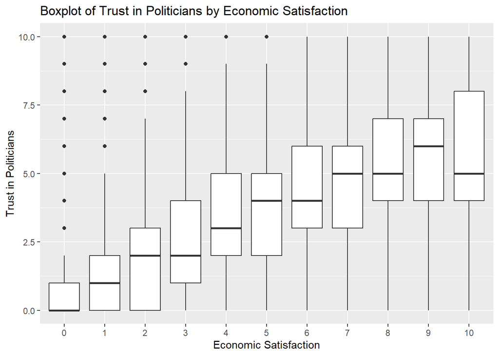

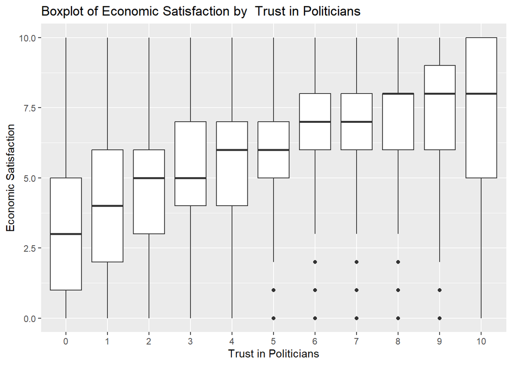

The two box plots illustrate the positive relationship between the two variables. People rating the economic situation as unsatisfying have very low trust in their politicians. The trustness increases whith increasing economic satisfaction (until economic situation = 9). For those who are very satisfied with economic situation (10) the trust is bit lower (significance unclear). When we change perspective and consideder the trust in politicians as X variable a similar pattern is observable: the higher the trust in politicians the higher their economic satisfaction.

### Heatmap

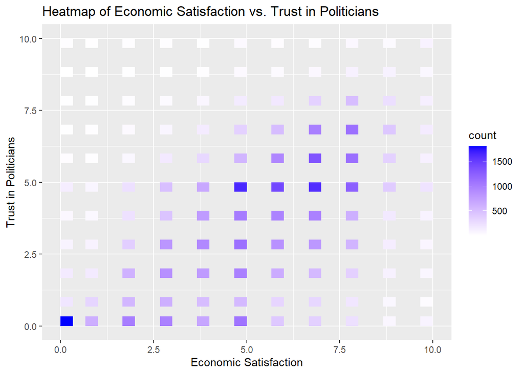

The heatmap shows in which combinations between the two variables the most observations can be counted. Many participants chose for both variables 0 or 5 (which could be bias due to selecting a “popular number”). Apart from that the observations we made before are confirmed: higher values for economic satisfaction, many 5 and 7 selections for economic satisfaction, positive relationsship.

### Plot the Linear Model

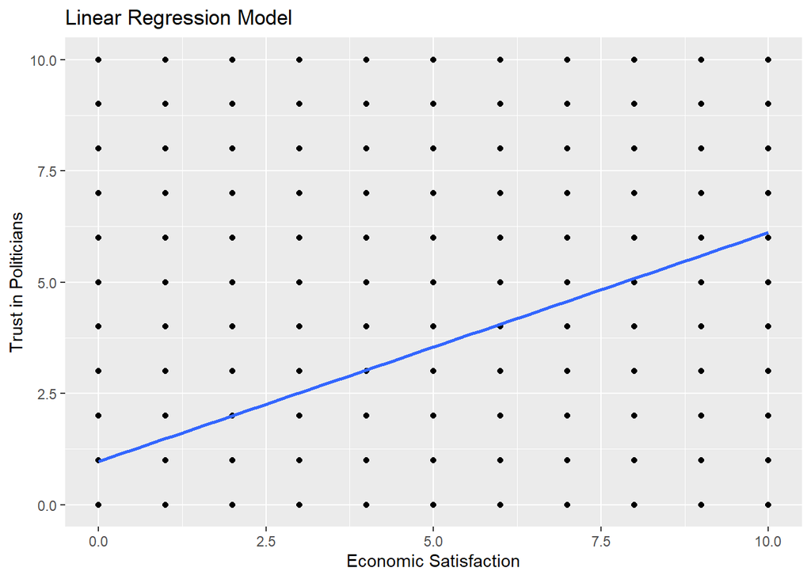

The linear regression model also shows the positive relationship between the variables.

## Conclusion

Based on these findings, it can be concluded that there is indeed a positive relationship between economic satisfaction and trust in politicians. Individuals who perceive the economy as performing well are more likely to express trust in political leaders. This underscores the importance of economic factors in shaping public perceptions of political leadership and governance. However, it’s essential to recognize that causality cannot be inferred from this analysis alone (omitted variables, reversed causality), and further research would be needed to explore the underlying mechanisms driving this relationship.